# Risk Factor Analysis

## Outcome Variable

**Outcome Variable:** haz

## Predictor Variables

**Intervention Variable:** impfloor

**Adjustment Set:**

unadjusted

## Stratifying Variables

The analysis was stratified on these variable(s):

- agecat
- studyid
- country

## Data Summary

| agecat | studyid | country | impfloor | n_cell | n |
| --- | --- | --- | --- | --- | --- |
| Birth | CMC-V-BCS-2002 | INDIA | 1 | 72 | 72 |
| Birth | CMC-V-BCS-2002 | INDIA | 0 | 0 | 72 |
| Birth | CONTENT | PERU | 1 | 2 | 2 |
| Birth | CONTENT | PERU | 0 | 0 | 2 |
| Birth | GMS-Nepal | NEPAL | 1 | 100 | 544 |
| Birth | GMS-Nepal | NEPAL | 0 | 444 | 544 |
| Birth | IRC | INDIA | 1 | 287 | 287 |
| Birth | IRC | INDIA | 0 | 0 | 287 |
| Birth | MAL-ED | BANGLADESH | 1 | 196 | 213 |
| Birth | MAL-ED | BANGLADESH | 0 | 17 | 213 |
| Birth | MAL-ED | BRAZIL | 1 | 58 | 60 |
| Birth | MAL-ED | BRAZIL | 0 | 2 | 60 |
| Birth | MAL-ED | INDIA | 1 | 35 | 41 |
| Birth | MAL-ED | INDIA | 0 | 6 | 41 |
| Birth | MAL-ED | NEPAL | 1 | 9 | 25 |
| Birth | MAL-ED | NEPAL | 0 | 16 | 25 |
| Birth | MAL-ED | PERU | 1 | 39 | 215 |
| Birth | MAL-ED | PERU | 0 | 176 | 215 |
| Birth | MAL-ED | SOUTH AFRICA | 1 | 87 | 96 |
| Birth | MAL-ED | SOUTH AFRICA | 0 | 9 | 96 |
| Birth | MAL-ED | TANZANIA, UNITED REPUBLIC OF | 1 | 7 | 119 |
| Birth | MAL-ED | TANZANIA, UNITED REPUBLIC OF | 0 | 112 | 119 |
| Birth | NIH-Birth | BANGLADESH | 1 | 533 | 605 |
| Birth | NIH-Birth | BANGLADESH | 0 | 72 | 605 |
| Birth | NIH-Crypto | BANGLADESH | 1 | 558 | 732 |
| Birth | NIH-Crypto | BANGLADESH | 0 | 174 | 732 |
| Birth | PROVIDE | BANGLADESH | 1 | 491 | 539 |
| Birth | PROVIDE | BANGLADESH | 0 | 48 | 539 |
| 6 months | CMC-V-BCS-2002 | INDIA | 1 | 257 | 257 |
| 6 months | CMC-V-BCS-2002 | INDIA | 0 | 0 | 257 |

[output cut: 54 more lines]

The following strata were considered:

- agecat: 24 months, studyid: CMC-V-BCS-2002, country: INDIA
- agecat: 24 months, studyid: CONTENT, country: PERU
- agecat: 24 months, studyid: GMS-Nepal, country: NEPAL
- agecat: 24 months, studyid: IRC, country: INDIA
- agecat: 24 months, studyid: MAL-ED, country: BANGLADESH
- agecat: 24 months, studyid: MAL-ED, country: BRAZIL
- agecat: 24 months, studyid: MAL-ED, country: INDIA
- agecat: 24 months, studyid: MAL-ED, country: NEPAL
- agecat: 24 months, studyid: MAL-ED, country: PERU
- agecat: 24 months, studyid: MAL-ED, country: SOUTH AFRICA
- agecat: 24 months, studyid: MAL-ED, country: TANZANIA, UNITED REPUBLIC OF
- agecat: 24 months, studyid: NIH-Birth, country: BANGLADESH
- agecat: 24 months, studyid: NIH-Crypto, country: BANGLADESH
- agecat: 24 months, studyid: PROVIDE, country: BANGLADESH
- agecat: 6 months, studyid: CMC-V-BCS-2002, country: INDIA
- agecat: 6 months, studyid: CONTENT, country: PERU
- agecat: 6 months, studyid: GMS-Nepal, country: NEPAL
- agecat: 6 months, studyid: IRC, country: INDIA
- agecat: 6 months, studyid: MAL-ED, country: BANGLADESH
- agecat: 6 months, studyid: MAL-ED, country: BRAZIL
- agecat: 6 months, studyid: MAL-ED, country: INDIA
- agecat: 6 months, studyid: MAL-ED, country: NEPAL
- agecat: 6 months, studyid: MAL-ED, country: PERU
- agecat: 6 months, studyid: MAL-ED, country: SOUTH AFRICA
- agecat: 6 months, studyid: MAL-ED, country: TANZANIA, UNITED REPUBLIC OF
- agecat: 6 months, studyid: NIH-Birth, country: BANGLADESH
- agecat: 6 months, studyid: NIH-Crypto, country: BANGLADESH
- agecat: 6 months, studyid: PROVIDE, country: BANGLADESH
- agecat: Birth, studyid: CMC-V-BCS-2002, country: INDIA
- agecat: Birth, studyid: CONTENT, country: PERU
- agecat: Birth, studyid: GMS-Nepal, country: NEPAL
- agecat: Birth, studyid: IRC, country: INDIA
- agecat: Birth, studyid: MAL-ED, country: BANGLADESH
- agecat: Birth, studyid: MAL-ED, country: BRAZIL
- agecat: Birth, studyid: MAL-ED, country: INDIA
- agecat: Birth, studyid: MAL-ED, country: NEPAL
- agecat: Birth, studyid: MAL-ED, country: PERU
- agecat: Birth, studyid: MAL-ED, country: SOUTH AFRICA
- agecat: Birth, studyid: MAL-ED, country: TANZANIA, UNITED REPUBLIC OF
- agecat: Birth, studyid: NIH-Birth, country: BANGLADESH
- agecat: Birth, studyid: NIH-Crypto, country: BANGLADESH
- agecat: Birth, studyid: PROVIDE, country: BANGLADESH

### Dropped Strata

Some strata were dropped due to rare outcomes:

- agecat: Birth, studyid: CMC-V-BCS-2002, country: INDIA
- agecat: Birth, studyid: CONTENT, country: PERU
- agecat: Birth, studyid: IRC, country: INDIA
- agecat: Birth, studyid: MAL-ED, country: BRAZIL
- agecat: 6 months, studyid: CMC-V-BCS-2002, country: INDIA
- agecat: 6 months, studyid: IRC, country: INDIA
- agecat: 6 months, studyid: MAL-ED, country: BRAZIL
- agecat: 24 months, studyid: CMC-V-BCS-2002, country: INDIA
- agecat: 24 months, studyid: IRC, country: INDIA
- agecat: 24 months, studyid: MAL-ED, country: BRAZIL

## Methods Detail

We’re interested in the causal parameters $E[Y_a]$ for all values of $a \in \mathcal{A}$. These parameters represent the mean outcome if, possibly contrary to fact, we intervened to set all units to have $A=a$. Under the randomization and positivity assumptions, these are identified by the statistical parameters $\psi_a=E_W[E_{Y|A,W}(Y|A=a,W)]$. In addition, we’re interested in the mean of $Y$, $E[Y]$ under no intervention (the observed mean). We will estimate these parameters by using SuperLearner to fit the relevant likelihood factors – $E_{Y|A,W}(Y|A=a,W)$ and $p(A=a|W)$, and then updating our likelihood fit using a joint TMLE.

For unadjusted analyses ($W=\{\}$), initial likelihoods were estimated using Lrnr_glm to estimate the simple $E(Y|A)$ and Lrnr_mean to estimate $p(A)$. For adjusted analyses, a small library containing Lrnr_glmnet, Lrnr_xgboost, and Lrnr_mean was used.

Having estimated these parameters, we will then use the delta method to estimate relative risks and attributable risks relative to a prespecified baseline level of $A$.

# Results Detail

## Results Plots

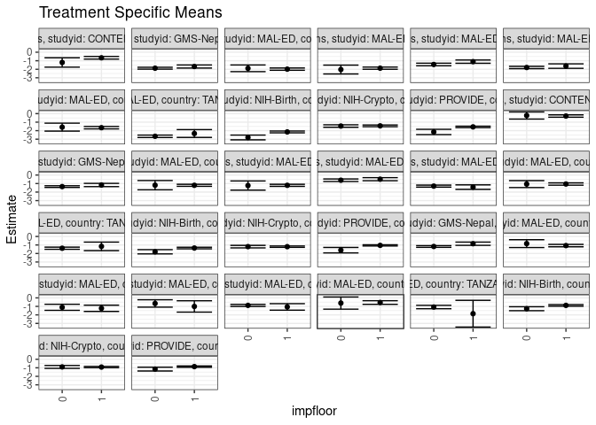

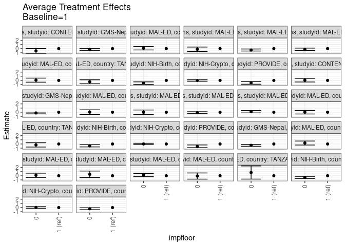

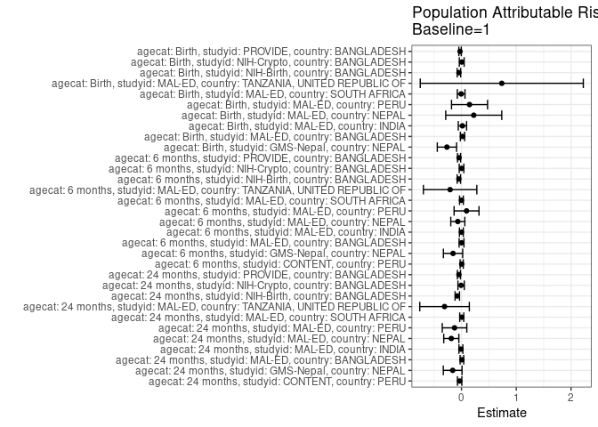

## Results Table

### Parameter: TSM

| agecat | studyid | country | intervention_level | baseline_level | estimate | ci_lower | ci_upper |
| --- | --- | --- | --- | --- | --- | --- | --- |
| Birth | GMS-Nepal | NEPAL | 1 | NA | -0.8520000 | -1.0423942 | -0.6616058 |
| Birth | GMS-Nepal | NEPAL | 0 | NA | -1.1775450 | -1.2780763 | -1.0770138 |
| Birth | MAL-ED | BANGLADESH | 1 | NA | -1.0714286 | -1.2141003 | -0.9287569 |
| Birth | MAL-ED | BANGLADESH | 0 | NA | -0.8411765 | -1.2999621 | -0.3823908 |
| Birth | MAL-ED | INDIA | 1 | NA | -1.2242857 | -1.5919558 | -0.8566156 |
| Birth | MAL-ED | INDIA | 0 | NA | -1.1066667 | -1.4622060 | -0.7511274 |
| Birth | MAL-ED | NEPAL | 1 | NA | -1.0066667 | -1.6704675 | -0.3428658 |
| Birth | MAL-ED | NEPAL | 0 | NA | -0.6568750 | -1.0897018 | -0.2240482 |
| Birth | MAL-ED | PERU | 1 | NA | -1.0610256 | -1.4430272 | -0.6790241 |
| Birth | MAL-ED | PERU | 0 | NA | -0.8815909 | -1.0041320 | -0.7590499 |
| Birth | MAL-ED | SOUTH AFRICA | 1 | NA | -0.5463218 | -0.7573107 | -0.3353330 |
| Birth | MAL-ED | SOUTH AFRICA | 0 | NA | -0.6111111 | -1.3247632 | 0.1025410 |
| Birth | MAL-ED | TANZANIA, UNITED REPUBLIC OF | 1 | NA | -1.8571429 | -3.4252117 | -0.2890740 |
| Birth | MAL-ED | TANZANIA, UNITED REPUBLIC OF | 0 | NA | -1.0753571 | -1.2760805 | -0.8746338 |
| Birth | NIH-Birth | BANGLADESH | 1 | NA | -0.8823171 | -0.9775574 | -0.7870768 |
| Birth | NIH-Birth | BANGLADESH | 0 | NA | -1.2739583 | -1.5068937 | -1.0410230 |
| Birth | NIH-Crypto | BANGLADESH | 1 | NA | -0.9139427 | -0.9914496 | -0.8364357 |
| Birth | NIH-Crypto | BANGLADESH | 0 | NA | -0.8952299 | -1.0641814 | -0.7262784 |
| Birth | PROVIDE | BANGLADESH | 1 | NA | -0.8591853 | -0.9382094 | -0.7801612 |
| Birth | PROVIDE | BANGLADESH | 0 | NA | -1.1502083 | -1.3743782 | -0.9260385 |
| 6 months | CONTENT | PERU | 1 | NA | -0.2825896 | -0.4199717 | -0.1452074 |
| 6 months | CONTENT | PERU | 0 | NA | -0.2201786 | -0.6413514 | 0.2009942 |
| 6 months | GMS-Nepal | NEPAL | 1 | NA | -1.1685470 | -1.3575442 | -0.9795498 |
| 6 months | GMS-Nepal | NEPAL | 0 | NA | -1.3555923 | -1.4555636 | -1.2556210 |
| 6 months | MAL-ED | BANGLADESH | 1 | NA | -1.2037104 | -1.3225777 | -1.0848431 |
| 6 months | MAL-ED | BANGLADESH | 0 | NA | -1.1907018 | -1.7345776 | -0.6468259 |
| 6 months | MAL-ED | INDIA | 1 | NA | -1.2054242 | -1.3265591 | -1.0842894 |
| 6 months | MAL-ED | INDIA | 0 | NA | -1.2311111 | -1.7710565 | -0.6911657 |
| 6 months | MAL-ED | NEPAL | 1 | NA | -0.4864401 | -0.6662715 | -0.3066088 |
| 6 months | MAL-ED | NEPAL | 0 | NA | -0.6082937 | -0.7553954 | -0.4611919 |
| 6 months | MAL-ED | PERU | 1 | NA | -1.4173994 | -1.6817556 | -1.1530432 |
| 6 months | MAL-ED | PERU | 0 | NA | -1.2995362 | -1.4175260 | -1.1815464 |
| 6 months | MAL-ED | SOUTH AFRICA | 1 | NA | -1.0541630 | -1.1904929 | -0.9178332 |
| 6 months | MAL-ED | SOUTH AFRICA | 0 | NA | -1.0620000 | -1.4685167 | -0.6554833 |
| 6 months | MAL-ED | TANZANIA, UNITED REPUBLIC OF | 1 | NA | -1.1627381 | -1.6643920 | -0.6610842 |
| 6 months | MAL-ED | TANZANIA, UNITED REPUBLIC OF | 0 | NA | -1.3826046 | -1.5092880 | -1.2559212 |
| 6 months | NIH-Birth | BANGLADESH | 1 | NA | -1.3581150 | -1.4521493 | -1.2640806 |
| 6 months | NIH-Birth | BANGLADESH | 0 | NA | -1.8004023 | -2.0487867 | -1.5520179 |
| 6 months | NIH-Crypto | BANGLADESH | 1 | NA | -1.1996182 | -1.2809541 | -1.1182824 |
| 6 months | NIH-Crypto | BANGLADESH | 0 | NA | -1.1958427 | -1.3444387 | -1.0472467 |
| 6 months | PROVIDE | BANGLADESH | 1 | NA | -1.0478845 | -1.1227684 | -0.9730006 |
| 6 months | PROVIDE | BANGLADESH | 0 | NA | -1.6108511 | -1.9322593 | -1.2894428 |
| 24 months | CONTENT | PERU | 1 | NA | -0.6533766 | -0.8098103 | -0.4969429 |
| 24 months | CONTENT | PERU | 0 | NA | -1.2025000 | -1.7501819 | -0.6548181 |
| 24 months | GMS-Nepal | NEPAL | 1 | NA | -1.6788194 | -1.8598006 | -1.4978383 |
| 24 months | GMS-Nepal | NEPAL | 0 | NA | -1.8780243 | -1.9873826 | -1.7686660 |
| 24 months | MAL-ED | BANGLADESH | 1 | NA | -1.9863333 | -2.1196399 | -1.8530268 |
| 24 months | MAL-ED | BANGLADESH | 0 | NA | -1.8873529 | -2.2788929 | -1.4958130 |
| 24 months | MAL-ED | INDIA | 1 | NA | -1.8757783 | -2.0041380 | -1.7474186 |
| 24 months | MAL-ED | INDIA | 0 | NA | -2.0333333 | -2.5534219 | -1.5132448 |
| 24 months | MAL-ED | NEPAL | 1 | NA | -1.1068367 | -1.2988388 | -0.9148346 |
| 24 months | MAL-ED | NEPAL | 0 | NA | -1.4409756 | -1.5926573 | -1.2892939 |
| 24 months | MAL-ED | PERU | 1 | NA | -1.6255442 | -1.8891056 | -1.3619828 |
| 24 months | MAL-ED | PERU | 0 | NA | -1.7933882 | -1.9285972 | -1.6581791 |
| 24 months | MAL-ED | SOUTH AFRICA | 1 | NA | -1.6499735 | -1.7905572 | -1.5093898 |
| 24 months | MAL-ED | SOUTH AFRICA | 0 | NA | -1.5850000 | -2.0510502 | -1.1189498 |
| 24 months | MAL-ED | TANZANIA, UNITED REPUBLIC OF | 1 | NA | -2.3341667 | -2.7919960 | -1.8763373 |
| 24 months | MAL-ED | TANZANIA, UNITED REPUBLIC OF | 0 | NA | -2.6617750 | -2.8032562 | -2.5202938 |
| 24 months | NIH-Birth | BANGLADESH | 1 | NA | -2.1473143 | -2.2555751 | -2.0390536 |
| 24 months | NIH-Birth | BANGLADESH | 0 | NA | -2.7987667 | -3.0780312 | -2.5195022 |
| 24 months | NIH-Crypto | BANGLADESH | 1 | NA | -1.4345376 | -1.5371506 | -1.3319246 |
| 24 months | NIH-Crypto | BANGLADESH | 0 | NA | -1.4551190 | -1.5994549 | -1.3107832 |
| 24 months | PROVIDE | BANGLADESH | 1 | NA | -1.5561257 | -1.6414102 | -1.4708412 |
| 24 months | PROVIDE | BANGLADESH | 0 | NA | -2.1507778 | -2.4622919 | -1.8392637 |

### Parameter: E(Y)

| agecat | studyid | country | intervention_level | baseline_level | estimate | ci_lower | ci_upper |
| --- | --- | --- | --- | --- | --- | --- | --- |
| Birth | GMS-Nepal | NEPAL | NA | NA | -1.1177022 | -1.2075344 | -1.0278700 |
| Birth | MAL-ED | BANGLADESH | NA | NA | -1.0530516 | -1.1896058 | -0.9164975 |
| Birth | MAL-ED | INDIA | NA | NA | -1.2070732 | -1.5254820 | -0.8886644 |
| Birth | MAL-ED | NEPAL | NA | NA | -0.7828000 | -1.1547571 | -0.4108429 |
| Birth | MAL-ED | PERU | NA | NA | -0.9141395 | -1.0364098 | -0.7918693 |
| Birth | MAL-ED | SOUTH AFRICA | NA | NA | -0.5523958 | -0.7550074 | -0.3497843 |
| Birth | MAL-ED | TANZANIA, UNITED REPUBLIC OF | NA | NA | -1.1213445 | -1.3341800 | -0.9085090 |
| Birth | NIH-Birth | BANGLADESH | NA | NA | -0.9289256 | -1.0178691 | -0.8399821 |
| Birth | NIH-Crypto | BANGLADESH | NA | NA | -0.9094945 | -0.9809370 | -0.8380521 |
| Birth | PROVIDE | BANGLADESH | NA | NA | -0.8851020 | -0.9601332 | -0.8100709 |
| 6 months | CONTENT | PERU | NA | NA | -0.2785256 | -0.4098735 | -0.1471776 |
| 6 months | GMS-Nepal | NEPAL | NA | NA | -1.3225094 | -1.4115793 | -1.2334396 |
| 6 months | MAL-ED | BANGLADESH | NA | NA | -1.2026806 | -1.3203025 | -1.0850586 |
| 6 months | MAL-ED | INDIA | NA | NA | -1.2070638 | -1.3255909 | -1.0885368 |
| 6 months | MAL-ED | NEPAL | NA | NA | -0.5534862 | -0.6681825 | -0.4387899 |
| 6 months | MAL-ED | PERU | NA | NA | -1.3248549 | -1.4336721 | -1.2160378 |
| 6 months | MAL-ED | SOUTH AFRICA | NA | NA | -1.0547925 | -1.1843544 | -0.9252306 |
| 6 months | MAL-ED | TANZANIA, UNITED REPUBLIC OF | NA | NA | -1.3700408 | -1.4930436 | -1.2470380 |
| 6 months | NIH-Birth | BANGLADESH | NA | NA | -1.4060639 | -1.4948910 | -1.3172368 |
| 6 months | NIH-Crypto | BANGLADESH | NA | NA | -1.1986783 | -1.2700937 | -1.1272630 |
| 6 months | PROVIDE | BANGLADESH | NA | NA | -1.0916915 | -1.1661176 | -1.0172654 |
| 24 months | CONTENT | PERU | NA | NA | -0.6868598 | -0.8388476 | -0.5348719 |
| 24 months | GMS-Nepal | NEPAL | NA | NA | -1.8396747 | -1.9349390 | -1.7444104 |
| 24 months | MAL-ED | BANGLADESH | NA | NA | -1.9783962 | -2.1050210 | -1.8517715 |
| 24 months | MAL-ED | INDIA | NA | NA | -1.8861894 | -2.0110006 | -1.7613783 |
| 24 months | MAL-ED | NEPAL | NA | NA | -1.2928054 | -1.4146944 | -1.1709164 |
| 24 months | MAL-ED | PERU | NA | NA | -1.7524710 | -1.8736426 | -1.6312994 |
| 24 months | MAL-ED | SOUTH AFRICA | NA | NA | -1.6450595 | -1.7797240 | -1.5103950 |
| 24 months | MAL-ED | TANZANIA, UNITED REPUBLIC OF | NA | NA | -2.6432311 | -2.7795797 | -2.5068826 |
| 24 months | NIH-Birth | BANGLADESH | NA | NA | -2.2235968 | -2.3265592 | -2.1206344 |
| 24 months | NIH-Crypto | BANGLADESH | NA | NA | -1.4412646 | -1.5249156 | -1.3576135 |
| 24 months | PROVIDE | BANGLADESH | NA | NA | -1.6024221 | -1.6857420 | -1.5191023 |

### Parameter: ATE

| agecat | studyid | country | intervention_level | baseline_level | estimate | ci_lower | ci_upper |
| --- | --- | --- | --- | --- | --- | --- | --- |
| Birth | GMS-Nepal | NEPAL | 1 | 1 | 0.0000000 | 0.0000000 | 0.0000000 |
| Birth | GMS-Nepal | NEPAL | 0 | 1 | -0.3255450 | -0.5408506 | -0.1102395 |
| Birth | MAL-ED | BANGLADESH | 1 | 1 | 0.0000000 | 0.0000000 | 0.0000000 |
| Birth | MAL-ED | BANGLADESH | 0 | 1 | 0.2302521 | -0.2502055 | 0.7107097 |
| Birth | MAL-ED | INDIA | 1 | 1 | 0.0000000 | 0.0000000 | 0.0000000 |
| Birth | MAL-ED | INDIA | 0 | 1 | 0.1176190 | -0.3938392 | 0.6290772 |
| Birth | MAL-ED | NEPAL | 1 | 1 | 0.0000000 | 0.0000000 | 0.0000000 |
| Birth | MAL-ED | NEPAL | 0 | 1 | 0.3497917 | -0.4426543 | 1.1422376 |
| Birth | MAL-ED | PERU | 1 | 1 | 0.0000000 | 0.0000000 | 0.0000000 |
| Birth | MAL-ED | PERU | 0 | 1 | 0.1794347 | -0.2217404 | 0.5806098 |
| Birth | MAL-ED | SOUTH AFRICA | 1 | 1 | 0.0000000 | 0.0000000 | 0.0000000 |
| Birth | MAL-ED | SOUTH AFRICA | 0 | 1 | -0.0647893 | -0.8089772 | 0.6793986 |
| Birth | MAL-ED | TANZANIA, UNITED REPUBLIC OF | 1 | 1 | 0.0000000 | 0.0000000 | 0.0000000 |
| Birth | MAL-ED | TANZANIA, UNITED REPUBLIC OF | 0 | 1 | 0.7817857 | -0.7990779 | 2.3626493 |
| Birth | NIH-Birth | BANGLADESH | 1 | 1 | 0.0000000 | 0.0000000 | 0.0000000 |
| Birth | NIH-Birth | BANGLADESH | 0 | 1 | -0.3916413 | -0.6432950 | -0.1399875 |
| Birth | NIH-Crypto | BANGLADESH | 1 | 1 | 0.0000000 | 0.0000000 | 0.0000000 |
| Birth | NIH-Crypto | BANGLADESH | 0 | 1 | 0.0187128 | -0.1671687 | 0.2045943 |
| Birth | PROVIDE | BANGLADESH | 1 | 1 | 0.0000000 | 0.0000000 | 0.0000000 |
| Birth | PROVIDE | BANGLADESH | 0 | 1 | -0.2910230 | -0.5287138 | -0.0533322 |
| 6 months | CONTENT | PERU | 1 | 1 | 0.0000000 | 0.0000000 | 0.0000000 |
| 6 months | CONTENT | PERU | 0 | 1 | 0.0624110 | -0.3806019 | 0.5054238 |
| 6 months | GMS-Nepal | NEPAL | 1 | 1 | 0.0000000 | 0.0000000 | 0.0000000 |
| 6 months | GMS-Nepal | NEPAL | 0 | 1 | -0.1870453 | -0.4008541 | 0.0267635 |
| 6 months | MAL-ED | BANGLADESH | 1 | 1 | 0.0000000 | 0.0000000 | 0.0000000 |
| 6 months | MAL-ED | BANGLADESH | 0 | 1 | 0.0130087 | -0.5437052 | 0.5697226 |
| 6 months | MAL-ED | INDIA | 1 | 1 | 0.0000000 | 0.0000000 | 0.0000000 |
| 6 months | MAL-ED | INDIA | 0 | 1 | -0.0256869 | -0.5790536 | 0.5276798 |
| 6 months | MAL-ED | NEPAL | 1 | 1 | 0.0000000 | 0.0000000 | 0.0000000 |
| 6 months | MAL-ED | NEPAL | 0 | 1 | -0.1218535 | -0.3541857 | 0.1104787 |
| 6 months | MAL-ED | PERU | 1 | 1 | 0.0000000 | 0.0000000 | 0.0000000 |
| 6 months | MAL-ED | PERU | 0 | 1 | 0.1178633 | -0.1716290 | 0.4073556 |
| 6 months | MAL-ED | SOUTH AFRICA | 1 | 1 | 0.0000000 | 0.0000000 | 0.0000000 |
| 6 months | MAL-ED | SOUTH AFRICA | 0 | 1 | -0.0078370 | -0.4366046 | 0.4209306 |
| 6 months | MAL-ED | TANZANIA, UNITED REPUBLIC OF | 1 | 1 | 0.0000000 | 0.0000000 | 0.0000000 |
| 6 months | MAL-ED | TANZANIA, UNITED REPUBLIC OF | 0 | 1 | -0.2198665 | -0.7372690 | 0.2975359 |
| 6 months | NIH-Birth | BANGLADESH | 1 | 1 | 0.0000000 | 0.0000000 | 0.0000000 |
| 6 months | NIH-Birth | BANGLADESH | 0 | 1 | -0.4422873 | -0.7078758 | -0.1766989 |
| 6 months | NIH-Crypto | BANGLADESH | 1 | 1 | 0.0000000 | 0.0000000 | 0.0000000 |
| 6 months | NIH-Crypto | BANGLADESH | 0 | 1 | 0.0037756 | -0.1656243 | 0.1731754 |
| 6 months | PROVIDE | BANGLADESH | 1 | 1 | 0.0000000 | 0.0000000 | 0.0000000 |
| 6 months | PROVIDE | BANGLADESH | 0 | 1 | -0.5629666 | -0.8929830 | -0.2329501 |
| 24 months | CONTENT | PERU | 1 | 1 | 0.0000000 | 0.0000000 | 0.0000000 |
| 24 months | CONTENT | PERU | 0 | 1 | -0.5491234 | -1.1187083 | 0.0204616 |
| 24 months | GMS-Nepal | NEPAL | 1 | 1 | 0.0000000 | 0.0000000 | 0.0000000 |
| 24 months | GMS-Nepal | NEPAL | 0 | 1 | -0.1992048 | -0.4106603 | 0.0122506 |
| 24 months | MAL-ED | BANGLADESH | 1 | 1 | 0.0000000 | 0.0000000 | 0.0000000 |
| 24 months | MAL-ED | BANGLADESH | 0 | 1 | 0.0989804 | -0.3146308 | 0.5125916 |
| 24 months | MAL-ED | INDIA | 1 | 1 | 0.0000000 | 0.0000000 | 0.0000000 |
| 24 months | MAL-ED | INDIA | 0 | 1 | -0.1575550 | -0.6932493 | 0.3781392 |
| 24 months | MAL-ED | NEPAL | 1 | 1 | 0.0000000 | 0.0000000 | 0.0000000 |
| 24 months | MAL-ED | NEPAL | 0 | 1 | -0.3341389 | -0.5788268 | -0.0894510 |
| 24 months | MAL-ED | PERU | 1 | 1 | 0.0000000 | 0.0000000 | 0.0000000 |
| 24 months | MAL-ED | PERU | 0 | 1 | -0.1678439 | -0.4640636 | 0.1283757 |
| 24 months | MAL-ED | SOUTH AFRICA | 1 | 1 | 0.0000000 | 0.0000000 | 0.0000000 |
| 24 months | MAL-ED | SOUTH AFRICA | 0 | 1 | 0.0649735 | -0.4218186 | 0.5517656 |
| 24 months | MAL-ED | TANZANIA, UNITED REPUBLIC OF | 1 | 1 | 0.0000000 | 0.0000000 | 0.0000000 |
| 24 months | MAL-ED | TANZANIA, UNITED REPUBLIC OF | 0 | 1 | -0.3276083 | -0.8068000 | 0.1515833 |
| 24 months | NIH-Birth | BANGLADESH | 1 | 1 | 0.0000000 | 0.0000000 | 0.0000000 |
| 24 months | NIH-Birth | BANGLADESH | 0 | 1 | -0.6514523 | -0.9509670 | -0.3519376 |
| 24 months | NIH-Crypto | BANGLADESH | 1 | 1 | 0.0000000 | 0.0000000 | 0.0000000 |
| 24 months | NIH-Crypto | BANGLADESH | 0 | 1 | -0.0205815 | -0.1976754 | 0.1565125 |
| 24 months | PROVIDE | BANGLADESH | 1 | 1 | 0.0000000 | 0.0000000 | 0.0000000 |
| 24 months | PROVIDE | BANGLADESH | 0 | 1 | -0.5946521 | -0.9176296 | -0.2716746 |

### Parameter: PAR

| agecat | studyid | country | intervention_level | baseline_level | estimate | ci_lower | ci_upper |
| --- | --- | --- | --- | --- | --- | --- | --- |
| Birth | GMS-Nepal | NEPAL | 1 | NA | -0.2657022 | -0.4417493 | -0.0896551 |
| Birth | MAL-ED | BANGLADESH | 1 | NA | 0.0183769 | -0.0208786 | 0.0576325 |
| Birth | MAL-ED | INDIA | 1 | NA | 0.0172125 | -0.0587357 | 0.0931607 |
| Birth | MAL-ED | NEPAL | 1 | NA | 0.2238667 | -0.2877278 | 0.7354611 |
| Birth | MAL-ED | PERU | 1 | NA | 0.1468861 | -0.1816483 | 0.4754206 |
| Birth | MAL-ED | SOUTH AFRICA | 1 | NA | -0.0060740 | -0.0759449 | 0.0637969 |
| Birth | MAL-ED | TANZANIA, UNITED REPUBLIC OF | 1 | NA | 0.7357983 | -0.7524434 | 2.2240401 |
| Birth | NIH-Birth | BANGLADESH | 1 | NA | -0.0466085 | -0.0782189 | -0.0149982 |
| Birth | NIH-Crypto | BANGLADESH | 1 | NA | 0.0044481 | -0.0397406 | 0.0486368 |
| Birth | PROVIDE | BANGLADESH | 1 | NA | -0.0259167 | -0.0482127 | -0.0036207 |
| 6 months | CONTENT | PERU | 1 | NA | 0.0040640 | -0.0248571 | 0.0329850 |
| 6 months | GMS-Nepal | NEPAL | 1 | NA | -0.1539624 | -0.3300810 | 0.0221561 |
| 6 months | MAL-ED | BANGLADESH | 1 | NA | 0.0010299 | -0.0430456 | 0.0451053 |
| 6 months | MAL-ED | INDIA | 1 | NA | -0.0016396 | -0.0369700 | 0.0336909 |
| 6 months | MAL-ED | NEPAL | 1 | NA | -0.0670460 | -0.1951214 | 0.0610293 |
| 6 months | MAL-ED | PERU | 1 | NA | 0.0925445 | -0.1348342 | 0.3199231 |
| 6 months | MAL-ED | SOUTH AFRICA | 1 | NA | -0.0006295 | -0.0350697 | 0.0338107 |
| 6 months | MAL-ED | TANZANIA, UNITED REPUBLIC OF | 1 | NA | -0.2073027 | -0.6951813 | 0.2805759 |
| 6 months | NIH-Birth | BANGLADESH | 1 | NA | -0.0479489 | -0.0790141 | -0.0168838 |
| 6 months | NIH-Crypto | BANGLADESH | 1 | NA | 0.0009399 | -0.0412325 | 0.0431124 |
| 6 months | PROVIDE | BANGLADESH | 1 | NA | -0.0438070 | -0.0721681 | -0.0154459 |
| 24 months | CONTENT | PERU | 1 | NA | -0.0334831 | -0.0736468 | 0.0066806 |
| 24 months | GMS-Nepal | NEPAL | 1 | NA | -0.1608552 | -0.3317887 | 0.0100782 |
| 24 months | MAL-ED | BANGLADESH | 1 | NA | 0.0079371 | -0.0254276 | 0.0413018 |
| 24 months | MAL-ED | INDIA | 1 | NA | -0.0104111 | -0.0461753 | 0.0253531 |
| 24 months | MAL-ED | NEPAL | 1 | NA | -0.1859687 | -0.3239077 | -0.0480297 |
| 24 months | MAL-ED | PERU | 1 | NA | -0.1269268 | -0.3511562 | 0.0973027 |
| 24 months | MAL-ED | SOUTH AFRICA | 1 | NA | 0.0049140 | -0.0319672 | 0.0417951 |
| 24 months | MAL-ED | TANZANIA, UNITED REPUBLIC OF | 1 | NA | -0.3090645 | -0.7612475 | 0.1431185 |
| 24 months | NIH-Birth | BANGLADESH | 1 | NA | -0.0762825 | -0.1166023 | -0.0359626 |
| 24 months | NIH-Crypto | BANGLADESH | 1 | NA | -0.0067270 | -0.0646159 | 0.0511619 |
| 24 months | PROVIDE | BANGLADESH | 1 | NA | -0.0462964 | -0.0746037 | -0.0179891 |